# Imports

```python
import numpy as np
import pandas as pd
import tensorflow as tf
import matplotlib.pyplot as plt
import seaborn as sns
from sklearn.metrics import precision_score,confusion_matrix, accuracy_score,f1_score, roc_auc_score,auc, roc_curve, recall_score,log_loss,classification_report, make_scorer
from sklearn.model_selection import train_test_split,StratifiedKFold, KFold, GridSearchCV,RepeatedStratifiedKFold,cross_val_score
import xgboost
from xgboost import XGBClassifier
from sklearn.ensemble import RandomForestClassifier
from sklearn.tree import DecisionTreeClassifier
from sklearn.linear_model import LogisticRegression
from mlxtend.plotting import plot_confusion_matrix
from sklearn.ensemble import BaggingClassifier
from imblearn.pipeline import Pipeline
from imblearn.over_sampling import SMOTE
from sklearn.model_selection import learning_curve,cross_validate
from mlxtend.evaluate import paired_ttest_5x2cv
from catboost import CatBoostClassifier
#reproducibility
SEED=6
```

# Importing Data

```python
data=pd.read_csv("Clean Transformed.csv")
```

We drop Region Code Column based on phase 2 results

```python
data=data.drop("Region_Code",axis=1)
```

```python
data.head()
```

|  | Age | Vehicle_Age_Ordinal | Annual_Premium | Policy_Sales_Channel | Vintage | Gender_Female | Gender_Male | Driving_License_0 | Driving_License_1 | Previously_Insured_0 | Previously_Insured_1 | Vehicle_Damage_No | Vehicle_Damage_Yes | Age_times_Annual | Response |
| --- | --- | --- | --- | --- | --- | --- | --- | --- | --- | --- | --- | --- | --- | --- | --- |
| 0 | 44 | 2.0 | 40454 | 26 | 217 | 0 | 1 | 0 | 1 | 1 | 0 | 0 | 1 | 1779976.0 | 1 |
| 1 | 47 | 2.0 | 38294 | 26 | 27 | 0 | 1 | 0 | 1 | 1 | 0 | 0 | 1 | 1799818.0 | 1 |
| 2 | 21 | 1.0 | 28619 | 152 | 203 | 0 | 1 | 0 | 1 | 0 | 1 | 1 | 0 | 600999.0 | 0 |
| 3 | 29 | 1.0 | 27496 | 152 | 39 | 1 | 0 | 0 | 1 | 0 | 1 | 1 | 0 | 797384.0 | 0 |
| 4 | 24 | 1.0 | 2630 | 160 | 176 | 1 | 0 | 0 | 1 | 1 | 0 | 0 | 1 | 63120.0 | 0 |

We transformed float type features to integer cause catboost model only supports integers

```python
#for catboost since it doesnt support float types
data["Vehicle_Age_Ordinal"] = data["Vehicle_Age_Ordinal"].astype(np.int)
data["Age_times_Annual"]=data["Age_times_Annual"].astype(np.int)
```

```python
print("\n\nDatatypes of features: \n",'-' * 20,"\n", data.dtypes)
```

```
Datatypes of features:
 --------------------
 Age                     int64
Vehicle_Age_Ordinal     int64
Annual_Premium          int64
Policy_Sales_Channel    int64
Vintage                 int64
Gender_Female           int64
Gender_Male             int64
Driving_License_0       int64
Driving_License_1       int64
Previously_Insured_0    int64
Previously_Insured_1    int64
Vehicle_Damage_No       int64
Vehicle_Damage_Yes      int64
Age_times_Annual        int64
Response                int64
dtype: object
```

```python
label=data['Response']

features=data.drop(['Response'], axis = 1)

X_train,X_test,Y_train,Y_test = train_test_split(features,label,test_size= 0.20,random_state=SEED,shuffle=True)
```

```python
X_train
```

|  | Age | Vehicle_Age_Ordinal | Annual_Premium | Policy_Sales_Channel | Vintage | Gender_Female | Gender_Male | Driving_License_0 | Driving_License_1 | Previously_Insured_0 | Previously_Insured_1 | Vehicle_Damage_No | Vehicle_Damage_Yes | Age_times_Annual |
| --- | --- | --- | --- | --- | --- | --- | --- | --- | --- | --- | --- | --- | --- | --- |
| 155259 | 26 | 1.0 | 32254 | 152 | 70 | 1 | 0 | 0 | 1 | 0 | 1 | 1 | 0 | 838604.0 |
| 386621 | 27 | 1.0 | 25862 | 151 | 289 | 1 | 0 | 0 | 1 | 1 | 0 | 0 | 1 | 698274.0 |
| 136666 | 47 | 0.0 | 53903 | 122 | 187 | 1 | 0 | 0 | 1 | 1 | 0 | 0 | 1 | 2533441.0 |
| 357901 | 43 | 2.0 | 60877 | 124 | 161 | 0 | 1 | 0 | 1 | 1 | 0 | 0 | 1 | 2617711.0 |
| 365964 | 48 | 0.0 | 30989 | 26 | 20 | 0 | 1 | 0 | 1 | 1 | 0 | 0 | 1 | 1487472.0 |
| ... | ... | ... | ... | ... | ... | ... | ... | ... | ... | ... | ... | ... | ... | ... |
| 266858 | 24 | 1.0 | 59353 | 152 | 237 | 0 | 1 | 0 | 1 | 1 | 0 | 0 | 1 | 1424472.0 |
| 239572 | 55 | 0.0 | 2630 | 9 | 268 | 0 | 1 | 0 | 1 | 0 | 1 | 1 | 0 | 144650.0 |
| 303331 | 44 | 0.0 | 38462 | 124 | 76 | 0 | 1 | 0 | 1 | 0 | 1 | 1 | 0 | 1692328.0 |
| 379593 | 30 | 1.0 | 38750 | 152 | 151 | 1 | 0 | 0 | 1 | 1 | 0 | 1 | 0 | 1162500.0 |
| 162698 | 22 | 1.0 | 24019 | 152 | 21 | 0 | 1 | 0 | 1 | 1 | 0 | 0 | 1 | 528418.0 |

362152 rows × 14 columns

# SMOTE

SMOTE stands for Synthetic Minority Oversampling Technique. This is a statistical technique for increasing the number of cases in your dataset in a balanced way. The module works by generating new instances from existing minority cases that you supply as input.

```python
# transform the dataset
X_train_oversampled, Y_train = SMOTE().fit_resample(X_train, Y_train)
X_train = pd.DataFrame(X_train_oversampled, columns=X_train.columns)
```

This cell is to make sure that the newly created dataset has an equal number of positive and negative occurrences is equal to avoid high bias for a certain class

```python
from collections import Counter
counter = Counter(Y_train)
# estimate scale_pos_weight value
estimate = counter[0] / counter[1]
print('Estimate: %.3f' % estimate)
```

```
Estimate: 1.000
```

This shows that the number of positive and negative responses (result class ) are equal.

# Part 1 - Hypothesis Testing

## Hypothesis Testing on models

We will revsit our models’ performance evaluations and comparisons and embed hypothesis testing to reveal whether or not any observed differences are significant.

We are going to perfom the Hypothesis Testing on the following Models:

- Random Forest
- Bagging Classifier
- CatBoost
- XGBoost

Leaving out the following models:

- kNN Classifier
- Neural Networks

The Reason we will not be including kNN and Neural Networks in the Hypothesis Testing is the poor performance demonstrated by these models. This performance was justified and explained in Phase 3 of the project.

#### Our Hypotheses Will be the following

**H0:** Both models perform equally and the two algorithms are not significantly different.

**H1:** Both models perform diffrently and the two algorithms are significantly different

Let’s assume a significance threshold of **α=0.05** for rejecting the null hypothesis that both algorithms perform equally well on the dataset and conduct the paired 5x2_cv ttest.

**Why is this method significant for our problem ?**

First, Forming the pairs as (Random Forest and Bagging Classifier) and (CatBoost and XGBoost) is significant because both algorithms in each pair operate similarly, after comparing these two pairs. We must pick the model with the highest significant accuracy.

**Why 5 by 2-fold CV t paired test ?**

As its name says the test runs five 2-fold cross validation for each classifier. Score differences are then used to compute the folowing t statistic :

$$ t = \frac{p_1^{(1)}}{\sqrt{\frac{1}{5}\sum_{i=1}^{5}{s_i^2}}} $$

where :

- $p_1^{(1)}$ is the classifiers' scores difference for the first fold of the first iteration
- $s_i^2$ is the estimated variance of the score difference for $i^{th}$ iteration. This variance computes as $ \left(p_i^{(1)} - \overline{p_i} \right)^2 + \left(p_i^{(2)} - \overline{p_i} \right)^2$
- $p_i^{(j)}$ is the classifiers' scores difference for the $i^{th}$ iteration and fold $j$
- $\overline{p}_i = \left( p_i^{1} + p_i^{2} \right) / 2$

What we need to know is that under the null hypothesis (i.e. both classifiers are statistically equal) the score difference between the two classifiers in each fold is assumed to follow a normal distribution. With this assumption statistic $t$ is assumed to follow a t distribution with 5 degrees of freedom.

To test the null hypothesis we compute the value of $t$ and check if it statisfies a t distribution with 5 degree of freedom. Namely we check if the value looks like an outlier or not. If the value stays close enough to 0 then the null hypothesis is satisfied and classifiers are asummed to be equal.

### Random Forest and Bagging Classifier

Here we will compare Random Forest's performance and Bagging Classifier's performance. The parameter chosen to fit the models are the parameters retrieved from phase 3 (using grid search).

We will start by fitting the models and then retrieving Kfold results to see if the resulting mean is out of a coincidence or if the results are clustered around the mean.

#### Random Forest model and results interpretation

```python
#fit with best parameters
RF=RandomForestClassifier(criterion='gini',min_samples_leaf=1,n_estimators=60,random_state=SEED,n_jobs=-1)
cv1 = StratifiedKFold(n_splits=10, random_state=SEED,shuffle=True)
scores1 = cross_val_score(RF, X_train, Y_train, scoring='f1', cv=cv1, n_jobs=-1)
print('Random Forest Classifier Mean f1: %.3f (%.3f)' % (scores1.mean(), scores1.std()))
```

```
Random Forest Classifier Mean f1: 0.911 (0.001)
```

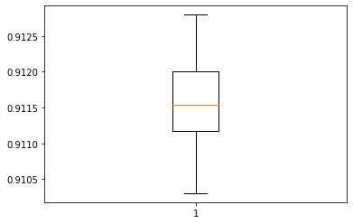

```python
plt.boxplot(scores1)
# show plot
plt.show()
```

Based on the BoxPlot and the standard deviation (0.001) we see that the average f1 scores of this model is representative, hence the mean average of f1 score given (91.1%) is representative.

Now we will fit our model, predict results, and compare predicted results with actual results to check the performance of our model.

Plotting the actual and predicted data (using ROC) is frequently used for visualizing and analyzing how the actual data correlate with those predicted by a model.

```python
rf = RF.fit(X_train,Y_train)
predicted_RF = rf.predict_proba(X_test)
```

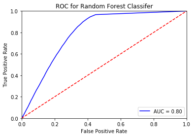

```python
import sklearn.metrics as metrics

preds = predicted_RF[:,1]
fpr, tpr, threshold = metrics.roc_curve(Y_test, preds)
roc_auc = metrics.auc(fpr, tpr)



plt.title('ROC for Random Forest Classifer')
plt.plot(fpr, tpr, 'b', label = 'AUC = %0.2f' % roc_auc)
plt.legend(loc = 'lower right')
plt.plot([0, 1], [0, 1],'r--')
plt.xlim([0, 1])
plt.ylim([0, 1])
plt.ylabel('True Positive Rate')
plt.xlabel('False Positive Rate')
plt.show()
```

The ROC curve shows that the predicted results are correlated with the test actual results, according to this and the f1 score of the model, provided there is no data leakage we can safely say that Random forest performs well.

#### Bagging Classifier model and results interpretation

```python
BC=BaggingClassifier(random_state=SEED,n_estimators=200)
cv2 = StratifiedKFold(n_splits=10, random_state=SEED,shuffle=True)
scores2 = cross_val_score(BC, X_train, Y_train, scoring='f1', cv=cv2, n_jobs=-1)
print('BaggingClassifier Mean f1: %.3f (%.3f)' % (scores2.mean(), scores2.std()))
```

```
BaggingClassifier Mean f1: 0.912 (0.001)
```

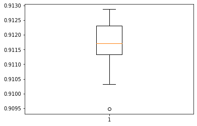

```python
plt.boxplot(scores2)
# show plot
plt.show()
```

Based on the BoxPlot and the standard deviation (0.001) we see that the average f1 scores of this model is representative, hence the mean average of f1 score given (91.2%) is representative.

Now we will fit our model, predict results, and compare predicted results with actual results to check the performance of our model.

Plotting the actual and predicted data (using ROC) is frequently used for visualizing and analyzing how the actual data correlate with those predicted by a model.

```python
bc = BC.fit(X_train,Y_train)
predicted_BC = bc.predict_proba(X_test)
```

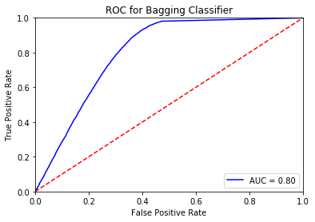

```python
import sklearn.metrics as metrics

preds = predicted_BC[:,1]
fpr, tpr, threshold = metrics.roc_curve(Y_test, preds)
roc_auc = metrics.auc(fpr, tpr)



plt.title('ROC for Bagging Classifier')
plt.plot(fpr, tpr, 'b', label = 'AUC = %0.2f' % roc_auc)
plt.legend(loc = 'lower right')
plt.plot([0, 1], [0, 1],'r--')
plt.xlim([0, 1])
plt.ylim([0, 1])
plt.ylabel('True Positive Rate')
plt.xlabel('False Positive Rate')
plt.show()
```

The ROC curve shows that the predicted results are correlated with the test actual results, according to this and the f1 score of the model, provided there is no data leakage we can safely say that Bagging Classifier performs well.

#### Now we perform 5 by 2-fold CV t paired test on both models

```python
# check if difference between algorithms is real
t, p = paired_ttest_5x2cv(estimator1=RF,
                          estimator2=BC,
                          X=X_train,
                          y=Y_train,
                          scoring='f1',
                          random_seed=SEED)
# summarize
print(f'The P-value is = {p:.3f}')
print(f'The t-statistics is = {t:.3f}')
# interpret the result
if p <= 0.05:
    print('Since p<0.05, We can reject the null-hypothesis that both models perform equally well on this dataset. We may conclude that the two algorithms are significantly different.')
else:
    print('Since p>0.05, we cannot reject the null hypothesis and may conclude that the performance of the two algorithms is not significantly different.')
```

```
The P-value is = 0.038
The t-statistics is = 2.805
Since p<0.05, We can reject the null-hypothesis that both models perform equally well on this dataset. We may conclude that the two algorithms are significantly different.
```

### CatBoost and XGBoost

Here we will compare CatBoost's performance and XGBoost's performance. The parameter chosen to fit the models are the parameters retrieved from phase 3 (using grid search).

We will start by fitting the models and then retrieving Kfold results to see if the resulting mean is out of a coincidence or if the results are clustered around the mean.

```python
Cat_model = CatBoostClassifier(n_estimators = 60,
                                random_seed = SEED,
                                task_type = 'CPU',
                                learning_rate=0.3,
                                reg_lambda =0.8,
                                loss_function='Logloss',
                                eval_metric='Logloss',
                                custom_loss = ['AUC']
                              )
```

```python
cv1 = KFold(n_splits=10, random_state=SEED,shuffle=True)
cv_score = cross_validate(Cat_model, X_train, Y_train, scoring='f1', cv=cv1, return_train_score=True)
```

[output not shown]

[output cut: 545 more lines]

[output not shown]

```python
print('Cat Boost Classifier Mean f1: %.3f (%.3f)' % (cv_score['train_score'].mean(),cv_score['train_score'].std()))
```

```
Cat Boost Classifier Mean f1: 0.866 (0.000)
```

[figure not shown]

```python
plt.boxplot(scores2)
# show plot
plt.show()
```

```python
CB = Cat_model.fit(X_train,Y_train)
predicted_CB = Cat_model.predict_proba(X_test)
```

[output not shown]

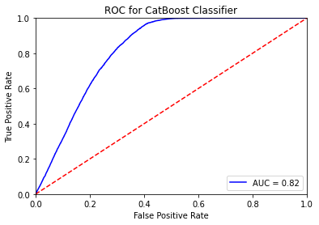

```python
import sklearn.metrics as metrics

preds = predicted_CB[:,1]
fpr, tpr, threshold = metrics.roc_curve(Y_test, preds)
roc_auc = metrics.auc(fpr, tpr)



plt.title('ROC for CatBoost Classifier')
plt.plot(fpr, tpr, 'b', label = 'AUC = %0.2f' % roc_auc)
plt.legend(loc = 'lower right')
plt.plot([0, 1], [0, 1],'r--')
plt.xlim([0, 1])
plt.ylim([0, 1])
plt.ylabel('True Positive Rate')
plt.xlabel('False Positive Rate')
plt.show()
```

The ROC curve shows that the predicted results are correlated with the test actual results, according to this and the f1 score of the model, provided there is no data leakage we can safely say that CarBoost performs well.

```python
XGB= XGBClassifier(random_state = SEED,
                             n_estimators =60,
                             reg_lambda =0.8, reg_alpha =1.2,
                             objective = 'binary:logistic',
                             learning_rate =0.3 , gamma = 5, colsample_bytree = 0.5, eval_metric = 'auc')
```

```python
cv2 = StratifiedKFold(n_splits=10, random_state=SEED,shuffle=True)
scores2 = cross_val_score(XGB, X_train, Y_train, scoring='f1', cv=cv2, n_jobs=-1)
print('XGBoost Classifier Mean f1: %.3f (%.3f)' % (scores2.mean(), scores2.std()))
```

```
XGBoost Classifier Mean f1: 0.864 (0.001)
```

[figure not shown]

```python
plt.boxplot(scores1)
# show plot
plt.show()
```

```python
XG = XGB.fit(X_train,Y_train)
predicted_XG = XG.predict_proba(X_test)
```

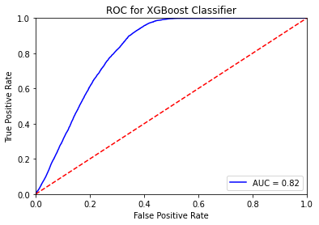

```python
import sklearn.metrics as metrics

preds = predicted_XG[:,1]
fpr, tpr, threshold = metrics.roc_curve(Y_test, preds)
roc_auc = metrics.auc(fpr, tpr)



plt.title('ROC for XGBoost Classifier')
plt.plot(fpr, tpr, 'b', label = 'AUC = %0.2f' % roc_auc)
plt.legend(loc = 'lower right')
plt.plot([0, 1], [0, 1],'r--')
plt.xlim([0, 1])
plt.ylim([0, 1])
plt.ylabel('True Positive Rate')
plt.xlabel('False Positive Rate')
plt.show()
```

#### Now we perform 5 by 2-fold CV t paired test on both models

```python
# check if difference between algorithms is real
t, p = paired_ttest_5x2cv(estimator1=Cat_model, estimator2=XGB, X=X_train, y=Y_train, scoring='f1', random_seed=SEED)
# summarize
print('P-value: %.3f, t-Statistic: %.3f' % (p, t))
# interpret the result
if p <= 0.05:
    print('Difference between mean performance is probably real')
else:
    print('Algorithms probably have the same performance')
```

[output not shown]

[output cut: 547 more lines]

[output not shown]

## Hypothesis testing for Data

Generally, data samples need to be representative of the domain and large enough to expose their distribution to analysis.

A statistical hypothesis test for comparing samples quantifies how likely it is to observe two data samples given the assumption that the samples have the same distribution.

The assumption of a statistical test is called the null hypothesis and we can calculate statistical measures and interpret them in order to decide whether or not to accept or reject the null hypothesis.

Namely, the observations in each sample are not independent because of SMOTE. As part of the k-fold cross-validation procedure, a given observation will be used in the training dataset (k-1) times. This means that the estimated skill scores are dependent, not independent, and in turn that the calculation of the t-statistic in the test will be misleadingly wrong along with any interpretations of the statistic and p-value.

### Parametric Statistical Hypothesis Test - Paired Student’s t-Test

We use paired student's test when we wish to compare the means between 2 data samples that are related in some way.

- Because the samples are not independent, we cannot use the Student’s t-test.
- Instead, we must use a modified version of the test that corrects for the fact that the data samples are dependent, called the paired Student’s t-test.

The t test tells you how significant the differences between groups are; In other words it lets you know if those differences (measured in means) could have happened by chance.

The t score is a ratio between the difference between two groups and the difference within the groups. The larger the t score, the more difference there is between groups. The smaller the t score, the more similarity there is between groups. A t score of 3 means that the groups are three times as different from each other as they are within each other. When you run a t test, the bigger the t-value, the more likely it is that the results are repeatable. A large t-score tells you that the groups are different. A small t-score tells you that the groups are similar.

A rejection of this hypothesis indicates that there is sufficient evidence that the means of the populations are different, and in turn that the distributions are not equal.

**Fail to Reject H0**: No difference between the sample means.

**Reject**: Some difference between the sample means.

```python
from scipy.stats import ttest_rel
```

We are getting a subset from the training set and compairing it to the testing set to see if both sets have same distribution

```python
Train_sample=pd.concat([X_train, Y_train], axis=1, sort=False)
Test_sample=pd.concat([X_test, Y_test], axis=1, sort=False)
```

```python
Train_sample =  Train_sample.sample(n=len(Test_sample))
```

```python
stat, p = ttest_rel(Train_sample, Test_sample)
# print('stat=%.3f, p=%.3f' % (stat, p))
if np.mean(p) > 0.05:
    print('Probably the same distribution')
else:
    print('Probably different distributions')
```

```
Probably the same distribution
```

Based on previous results we fail to reject H0, so there is no difference between the training and the testing data. Therefore, we conclude that the testing data is representative of the training data.

### Correlation Test - Pearson’s Correlation Coefficient

Tests whether two samples have a linear relationship.

**Assumptions:**

- Observations in each sample are independent and identically distributed (iid).
- Observations in each sample are normally distributed.
- Observations in each sample have the same variance.

**Interpretation**

**H0:** the two samples are independent.

**H1:** there is a dependency between the samples.

```python
from scipy.stats import pearsonr
```

```python
stat, p = pearsonr(X_train["Age"], X_train["Annual_Premium"])
print('stat=%.3f, p=%.3f' % (stat, p))
if p > 0.05:
    print('Probably independent')
else:
    print('Probably dependent')
```

```
stat=0.100, p=0.000
Probably dependent
```

After applying Pearson’s test on Age and Annual premium, we got the following results: p=0 and stat= 0.100. Our aim is to test the null hypothesis that the true correlation coefficient ρ is equal to 0. So we got that these features are probably dependent. As the age increases the cost of the insurance increases.

```python
stat, p = pearsonr(X_train["Gender_Male"], X_train["Vehicle_Damage_Yes"])
print('stat=%.3f, p=%.3f' % (stat, p))
if p > 0.05:
    print('Probably independent')
else:
    print('Probably dependent')
```

```
stat=-0.021, p=0.000
Probably dependent
```

# Part 2 - Revisiting Best Model

## Our Evaluation Matrices

Accuracy is used when the True Positives and True negatives are more important while **F1-score** is used when the False Negatives and False Positives are crucial. In our problem, **F1-score** is a better metric to evaluate our model because it is shows both precision and recall.

$$ F1 =\frac { 2 \times \text{precision} \times \text{recall}}{\text{precision} + \text{recall}} $$

In **pattern recognition**, information retrieval, and classification, precision is the fraction of relevant instances among the retrieved instances, while recall is the fraction of the total amount of relevant instances that were retrieved.

Therefore, our first matrics to evaluate the models in order to get the best one is F1-Score, cause it suits our problem of pattern recognition to help specialists know if a person is willing to buy in their auto-insurance program or not.

Our Second Matrix is **ROC** since Receiver Operating Characteristic curve is a graph showing the performance of a classification model at all classification thresholds. This curve plots two parameters: True Positive Rate. False Positive Rate

## Best Model

Therefore we are going to accept that **Bagging Classifier is our best model** and proceed with it.

## Revisiting Best model performance before and after Feature Selection .

### Before Feature Selection

Here we're going to fit a Bagging Classifier model with the same hyper parameters used in the previous step using all the available data.

```python
BC=BaggingClassifier(random_state=SEED,n_estimators=200)
cv2 = StratifiedKFold(n_splits=10, random_state=SEED,shuffle=True)
scores1 = cross_val_score(BC, X_train, Y_train, scoring='f1', cv=cv2, n_jobs=3)
print('BaggingClassifier Mean f1: %.3f (%.3f)' % (scores1.mean(), scores1.std()))
```

```
BaggingClassifier Mean f1: 0.916 (0.001)
```

### After Feature Selection

In the following set we are going to fit a Bagging Classifier Model with the same hyper parameters as the previous step except that we will be using only the data the best features already found in Phase 2 using feature engineering and dimensionality.

These columns are the following sorted by most important to less:

- Age
- Annual Premium
- Vehicle Damage (Yes)
- Policy Sales Channel
- Gender (Male and Female)
- Vehicle Age

**Preparing the data**

```python
Selected_X__train = X_train[['Age','Annual_Premium','Vehicle_Damage_Yes','Policy_Sales_Channel','Gender_Male','Gender_Female','Vehicle_Age_Ordinal']]
```

**Fitting the model**

```python
FE_BC=BaggingClassifier(random_state=SEED,n_estimators=200)
FE_cv = StratifiedKFold(n_splits=10, random_state=SEED,shuffle=True)
scores2 = cross_val_score(FE_BC, Selected_X__train, Y_train, scoring='f1', cv=FE_cv, n_jobs=3)
print('BaggingClassifier Mean f1: %.3f (%.3f)' % (scores2.mean(), scores2.std()))
```

```
BaggingClassifier Mean f1: 0.871 (0.001)
```

### Compare the model's results

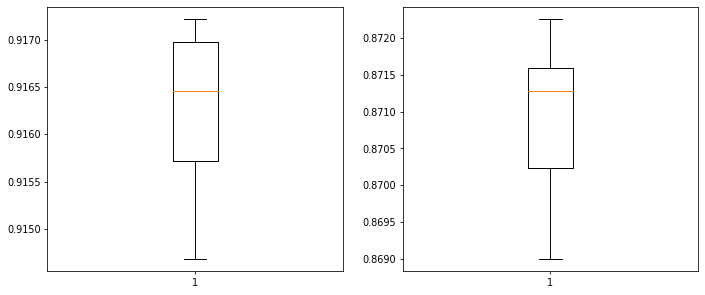

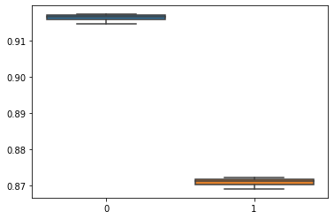

```python
fig, axes = plt.subplots(nrows=1, ncols=2, figsize=(12, 5), dpi=70, facecolor='w', edgecolor='k')
ax0, ax1 = axes.flatten()
ax0.boxplot(scores1)
ax1.boxplot(scores2)


# show plot
plt.show()
sns.boxplot(data=[scores1,scores2])
```

### Interpretation

Then we plotted the following models on 2 different boxplots, we can see in the first box plot (Before Feature Selection) that the upper quartile is approximately 0.9170, the lower quartile is approximately 0.9157, and the median is equal to 0.916. Where the second boxplot (After Feature Selection), the upper quartile is approximately equal to 0.8717, the lower quartile is approximately equal to 0.8702, and the median is equal to 0.871.

We can determine the model was more accurate on the dataset before feature selection, due to the results interpreted from the boxplots above.

### Hypothesis testing using Paired Samples t Test

#### Why Paired Samples t Test ?

The Paired Samples t Test compares two means that are from the same individual, object, or related units (According to kent state university, Ohio). The two means can represent things like:

- A measurement taken at two different times (e.g., pre-test and post-test with an intervention administered between the two time points)
- A measurement taken under two different conditions (e.g., completing a test under a "control" condition and an "experimental" condition)
- Measurements taken from two halves or sides of a subject or experimental unit (e.g., measuring hearing loss in a subject's left and right ears).

The purpose of the test is to determine whether there is statistical evidence that the mean difference between paired observations on a particular outcome is significantly different from zero. The Paired Samples t Test is a **parametric test**.

Our problem matches the first case cause we are trying to compare two means pre and post-intervention.In this case, the intervention is removing some features and performing the testing only on a selected number of features generated after feature selection.

```python
from scipy import stats
tStat, pValue =  stats.ttest_rel(scores1, scores2)
print("P-Value:{0} T-Statistic:{1}".format(pValue,tStat))
```

```
P-Value:5.151006190520654e-16 T-Statistic:128.95743595789733
```

After doing the paired t-test on the scores we got from the model before and after the feature selection we got the p-value and t-statistic. P values evaluate how well the sample data support the devil’s advocate argument that the null hypothesis is true. It measures how compatible your data are with the null hypothesis.

- High P values: your data are likely with a true null.
- Low P values: your data are unlikely with a true null.

# Part 4 - Wrapping up the project

An Insurance company has provided Health Insurance to its customers now they need help in building a model to predict whether the policyholders from the past year will also be interested in Auto Insurance provided by the company. In other words, predicting the probability of success of a potential new service for insurance companies to offer the company a clear and objective view of the risk they are taking if they decide to launch this product and help them decide where to launch it if they decided to.

# The main achievements

### Determining Important Features

According to our dataset, we found that using feature importance would be helpful since feature importance refers to techniques that assign a score to input features based on how useful they are at predicting a target variable. Feature importance scores can be used to help interpret the data, but they can also be used directly to help rank and select features that are most useful to a predictive model.

### Performing Feature Engineering

We decided not to do any feature engineering on our categorical columns. After performing we got a new feature which is the product of the 2 columns in question. we named this feature "Age_times_Annual". To validate the efficacy of our feature engineering, we plotted 2 plots, the first of which is the responses based on our new feature and Annual_Premium, and the second being with our new feature and the Age. The plots we got showed data that is more linearly separable, although not to a drastically better degree.

### Performing Dimensionality Reduction

In order to reduce dimensionality we performed **PCA**. PCA is a method for reducing the dimensionality of data. In PCA, data with m-columns (features) is projected into a subspace with m or fewer columns, whilst retaining the essence of the original data.

Kindly find below some of the visualizations we used to perform PCA

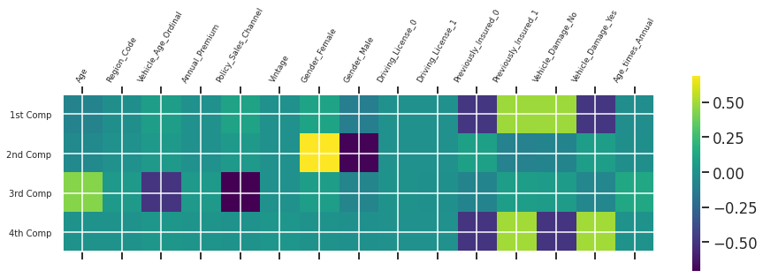

The Figure above is describing the relation between components

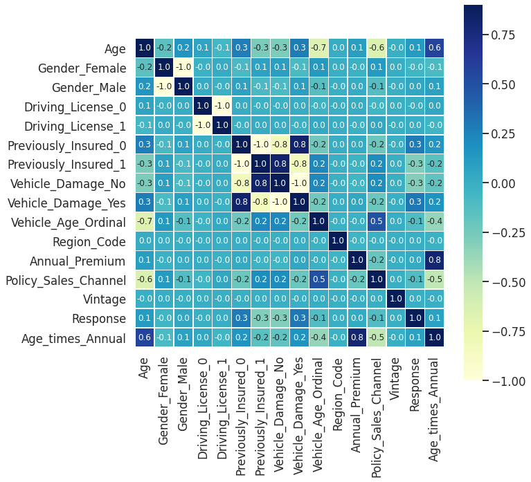

The Figure above is describing the correlation between components

After performing PCA and analyzing the results, we modified the data where we **dropped the region code feature** since by studying the correlations, region code has **0.0 correlation** with all features i.e there’s no relation.

### Exploratory data analysis (EDA)

After achieving PCA we went down to perform Exploratory data analysis (EDA) because it is a critical part of the data science process, and the first step toward building a model.

In order to more understand the data before fitting it to a model, we must explore it using graphs and plots so we started by preparing the data by classifying the categorical and numerical values and then plotting all features that we have against other significantly related features after analyzing the problem and making a clear vision on the way to approach it. Feature selection and PCA played a major role in deciding what features to plot against what features and what are the values that are important to visualize and analyze.

Kindly find attached some visulization graphs we used to analyze the data

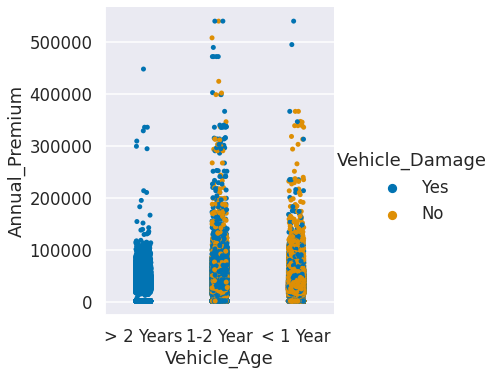

The plot above visualizes vehicle damage and annual premium against vehicle age

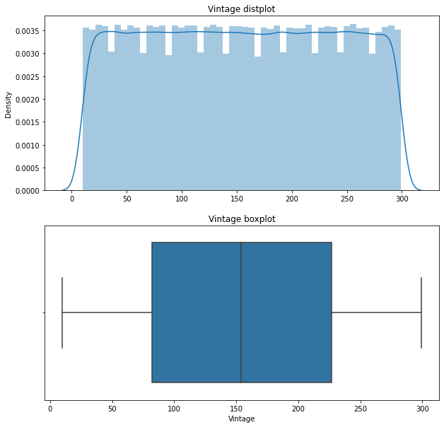

The plot above visulizes the number of Days the Customer has been associated with the company

### Pattern Analysis Using Kmenas Clustering

The last step before fitting our models was performing Kmeans Clustering to get a clearer understanding of the data and the problem we are dealing with. After plotting the values we came to realize that the data is divided into two clusters and that the centroids of the clusters where pretty close in each group and the data points scattered along with the plot, we could also find that all the four centroids are in the first half of the X-axis (between 0 and 0.5).

### Fitting Machine Learning Models

We attempted to train multiple models and chose the best one based on the following **matrices**:

- Accuracy.
- F-score.
- Receiver operating characteristic (ROC) and Area under the ROC Curve (AUC).
- Confusion Matrix

The **models** that we are trained are the following:

- Bagging Decision Tree
- Random Forest
- XBoost
- CATBoost
- Neural Network
- kNN

### Understanding the Data Limitation

The problem that we faced when we wanted to perform training was that we had a majority class (which we could easily condlude from the EDA part) and since are trying to solve is a binary classification problem, seeing that the ratio of negative response to positive response is **10:1** in our dataset, we had to find a solution. First, we ran our models on the dataset as is, to make a baseline (so we can see how much our modified datasets improve the results). Next, we tried **cost-sensitive learning** (by assigning a higher weight to the positive response). This method produced marginally better results, not enough to call it a real improvement and certainly not enough to call a good model. Instead, we tried using **SMOTE**.

### Overcomming the Limitation

We used SMOTE to **statistically** increase the number of cases in your dataset in a balanced way. Although we succeeded to build a balanced dataset, SMOTE was not sophisticated enough to fix our large imbalance issue. Other solutions might have been possible such as cost-sensitive ensembles, probabilistic predictions, and meta-learning, but we decided to go with SMOTE due to the time constraint.

### Interpreting Machine Learning Results

After fitting our models twice (once on all the features and once on the selected features) we could conclude that **Decision tree classifiers** performed way better then other models and this is because of the binary classification nature of the problem. Using **SMOT** was helpful to help balance the data but it created another problem of overfitting for some classes and underfitting for others which led to a huge decrease in some other models performance such as neural networks.

The main issue with the current model is despite the acceptable accuracy and Fmeasure, the huge amount of **false positives** predicted by most of our models is a major drawback for these models.

### Hypothesis Testing

We revsited our models’ performance evaluations and comparisons and embed hypothesis testing to reveal whether or not any observed differences are significant. We performed hypothesis testing only on significant models leaving out the poorly performanceed models.

So hypothesis testing was performed in **Decision tree classifiers** and on the data to find out if the correlating between features is significant or if the testing data is representing the training data.

Using multiple hypothesis tests such as Paired Student’s t-Test and 5x2 CV paired test we could conclude the correlation between features and between testing and training data. And getting values for our matrices (ROC and F1-Score) and matching them with hypothesis testing we could determine our best model.

### Choosing the Best Model

The choice of these matrices is convenient to our type of binary classification problem because they involve studying precision and recall which are both critical in our **business situation** for our future potential clients.

## Growth Potential

Building an accurate model to predict whether a customer would be interested in Vehicle Insurance is extremely helpful for the company because it can then accordingly plan its communication strategy to reach out to those customers and optimize its business model and revenue.

Having insurance companies benefiting from Data Science and introduce AI and statistics to solve statistical problems and find business solutions is a new trend that our project might benefit from.

**Giving the ability** to insurance companies to use their client's data to assess their policyholders ' willingness to buy car insurance from their company will be our selling point. This way, they will be able to assess the percentage of potential new auto insurance clients and direct their communication and advertising accordingly, and will eventually open the door to a whole new area of co-selling products and policies in the insurance field.

The **growth** and robustness of Business Intelligence solutions heavily rely on Data. Having a customer that is willing to invest in their data and expand their branches doubling their revenues will be the backbone of our project's growth. Getting a client will mean getting funds for additional researches and exploring new fields of data by adding features and increasing the number of our study samples to make it representative for multiple countries or states is the optimal growth of auto-health insurance co-sell models. After implementing successfully this project, another implementation will be using data to help find appropriate packages and premiums auto-insurance clients or even more exploring new areas of insurance that might benefit from data science to double its gainings and open up to new opportunities.

## Limitations

On the other hand, we had another type of time constraint, since the project phases are always due at a limited amount of time, and since machine learning algorithms and searching for best hyperparameters uses a lot of computational power and time we had a shortcoming when it came to this. In addition, after carefully studying the data, different approaches could be used to solve the problem, for example, we could have used meta-learning instead of SMOTE to overcome the data imbalance or used a more carefully studied neural network that fits the data we are handling and the problem we are solving.

## Controlling and Improving Limitations

Data Limitations are out of the control of the data scientists, gathering data is resources extensive since it is based on interviewing people and filling surveys, it's not entirely part of the Data Scientist's job. The data scientist could direct statistics and business and marketing teams who are leading the survey control towards the field and specifications he or she is looking for. Knowing the political and economic situation, linking features, and increasing dimensions is all part of the data scientist's job and it is done through data scraping, PCA, and EDA. By crossing and engineering features, the data scientist will increase features, discover new ones, or even ask the survey team to target another geographic location.

On the other hand, the time and computation limitations are also part of the data scientist's responsibility to research and read about alternative less computation expensive methods to tackle the problem. In many situations, changing one hyperparameter might highly affect positively both computation time and the model's performance.